# Part I - (Prosper Loan Data Exploration)

## Preliminary Wrangling

```python
# import all packages and set plots to be embedded inline
import numpy as np
import pandas as pd
import matplotlib.pyplot as plt
import seaborn as sb

%matplotlib inline
```

```python
import csv
loan_data = pd.read_csv("prosperLoanData.csv", engine='python',error_bad_lines=False,
                 encoding='utf-8')
loan_data.head()
```

```
Skipping line 71849: unexpected end of data
```

|  | ListingKey | ListingNumber | ListingCreationDate | CreditGrade | Term | LoanStatus | ClosedDate | BorrowerAPR | BorrowerRate | LenderYield | ... | LP_ServiceFees | LP_CollectionFees | LP_GrossPrincipalLoss | LP_NetPrincipalLoss | LP_NonPrincipalRecoverypayments | PercentFunded | Recommendations | InvestmentFromFriendsCount | InvestmentFromFriendsAmount | Investors |
| --- | --- | --- | --- | --- | --- | --- | --- | --- | --- | --- | --- | --- | --- | --- | --- | --- | --- | --- | --- | --- | --- |
| 0 | 1021339766868145413AB3B | 193129 | 2007-08-26 19:09:29.263000000 | C | 36 | Completed | 2009-08-14 00:00:00 | 0.16516 | 0.1580 | 0.1380 | ... | -133.18 | 0.0 | 0.0 | 0.0 | 0.0 | 1.0 | 0 | 0 | 0.0 | 258 |
| 1 | 10273602499503308B223C1 | 1209647 | 2014-02-27 08:28:07.900000000 | NaN | 36 | Current | NaN | 0.12016 | 0.0920 | 0.0820 | ... | 0.00 | 0.0 | 0.0 | 0.0 | 0.0 | 1.0 | 0 | 0 | 0.0 | 1 |
| 2 | 0EE9337825851032864889A | 81716 | 2007-01-05 15:00:47.090000000 | HR | 36 | Completed | 2009-12-17 00:00:00 | 0.28269 | 0.2750 | 0.2400 | ... | -24.20 | 0.0 | 0.0 | 0.0 | 0.0 | 1.0 | 0 | 0 | 0.0 | 41 |
| 3 | 0EF5356002482715299901A | 658116 | 2012-10-22 11:02:35.010000000 | NaN | 36 | Current | NaN | 0.12528 | 0.0974 | 0.0874 | ... | -108.01 | 0.0 | 0.0 | 0.0 | 0.0 | 1.0 | 0 | 0 | 0.0 | 158 |
| 4 | 0F023589499656230C5E3E2 | 909464 | 2013-09-14 18:38:39.097000000 | NaN | 36 | Current | NaN | 0.24614 | 0.2085 | 0.1985 | ... | -60.27 | 0.0 | 0.0 | 0.0 | 0.0 | 1.0 | 0 | 0 | 0.0 | 20 |

5 rows × 81 columns

```python
print(loan_data.shape)
print(loan_data.info())
```

```
(71847, 81)
<class 'pandas.core.frame.DataFrame'>
RangeIndex: 71847 entries, 0 to 71846
Data columns (total 81 columns):
ListingKey                             71847 non-null object
ListingNumber                          71847 non-null int64
ListingCreationDate                    71847 non-null object
CreditGrade                            18249 non-null object
Term                                   71847 non-null int64
LoanStatus                             71847 non-null object
ClosedDate                             34803 non-null object
BorrowerAPR                            71838 non-null float64
BorrowerRate                           71847 non-null float64
LenderYield                            71847 non-null float64
EstimatedEffectiveYield                53516 non-null float64
EstimatedLoss                          53516 non-null float64
EstimatedReturn                        53516 non-null float64
ProsperRating (numeric)                53516 non-null float64
ProsperRating (Alpha)                  53516 non-null object
ProsperScore                           53516 non-null float64
ListingCategory (numeric)              71847 non-null int64
BorrowerState                          68359 non-null object
Occupation                             69637 non-null object
EmploymentStatus                       70451 non-null object
EmploymentStatusDuration               67044 non-null float64
IsBorrowerHomeowner                    71847 non-null bool
CurrentlyInGroup                       71847 non-null bool
GroupKey                               8346 non-null object
DateCreditPulled                       71847 non-null object
CreditScoreRangeLower                  71476 non-null float64
CreditScoreRangeUpper                  71476 non-null float64
FirstRecordedCreditLine                71416 non-null object
CurrentCreditLines                     67058 non-null float64
OpenCreditLines                        67058 non-null float64
TotalCreditLinespast7years             71416 non-null float64
OpenRevolvingAccounts                  71847 non-null int64
OpenRevolvingMonthlyPayment            71847 non-null float64
InquiriesLast6Months                   71416 non-null float64
TotalInquiries                         71122 non-null float64
CurrentDelinquencies                   71416 non-null float64
```

[output cut: 33 more lines]

```
LP_CustomerPrincipalPayments           71847 non-null float64
LP_InterestandFees                     71847 non-null float64
LP_ServiceFees                         71847 non-null float64
LP_CollectionFees                      71847 non-null float64
LP_GrossPrincipalLoss                  71847 non-null float64
LP_NetPrincipalLoss                    71847 non-null float64
LP_NonPrincipalRecoverypayments        71847 non-null float64
PercentFunded                          71847 non-null float64
Recommendations                        71847 non-null int64
InvestmentFromFriendsCount             71847 non-null int64
InvestmentFromFriendsAmount            71847 non-null float64
Investors                              71847 non-null int64
dtypes: bool(3), float64(50), int64(11), object(17)
memory usage: 43.0+ MB
None
```

### What is the structure of your dataset?

71847 rows , 81 columns

### What is/are the main feature(s) of interest in your dataset?

LoanStatus

### What features in the dataset do you think will help support your investigation into your feature(s) of interest?

1.BorrowerRate 2.ProsperRating (numeric) 3.ProsperRating (Alpha) 4.ProsperScore 5.ListingCategory 6.BorrowerState 7.Occupation 8.EmploymentStatus 9.EmploymentStatusDuration 10.IsBorrowerHomeowner 11.DebtToIncomeRatio 12.IncomeRange 13.StatedMonthlyIncome 14.CurrentlyInGroup 15.Recommendations

a subset of the dataset will be create to aonly have the above columns. this will reduce the amount of data to work with and thus make the exploration easier and faster.

```python
loansdata = loan_data[['LoanStatus','BorrowerRate','ProsperRating (numeric)','ProsperRating (Alpha)', 'ProsperScore','ListingCategory (numeric)',
                       'BorrowerState','Occupation','EmploymentStatus','EmploymentStatusDuration','IsBorrowerHomeowner',
                       'DebtToIncomeRatio', 'IncomeRange','StatedMonthlyIncome','CurrentlyInGroup','Recommendations']]

loansdata=loansdata.dropna()
print(loansdata.shape)
loansdata.info()
```

```
(48169, 16)
<class 'pandas.core.frame.DataFrame'>
Int64Index: 48169 entries, 1 to 71846
Data columns (total 16 columns):
LoanStatus                   48169 non-null object
BorrowerRate                 48169 non-null float64
ProsperRating (numeric)      48169 non-null float64
ProsperRating (Alpha)        48169 non-null object
ProsperScore                 48169 non-null float64
ListingCategory (numeric)    48169 non-null int64
BorrowerState                48169 non-null object
Occupation                   48169 non-null object
EmploymentStatus             48169 non-null object
EmploymentStatusDuration     48169 non-null float64
IsBorrowerHomeowner          48169 non-null bool
DebtToIncomeRatio            48169 non-null float64
IncomeRange                  48169 non-null object
StatedMonthlyIncome          48169 non-null float64
CurrentlyInGroup             48169 non-null bool
Recommendations              48169 non-null int64
dtypes: bool(2), float64(6), int64(2), object(6)
memory usage: 5.6+ MB
```

```python
categorY = ['Current','FinalPaymentInProgress','Completed','Past Due (1-15 days)','Past Due (16-30 days)','Past Due (31-60 days)',
              'Past Due (61-90 days)','Past Due (91-120 days)','Past Due (>120 days)','Chargedoff','Defaulted',]

ordered= pd.api.types.CategoricalDtype(ordered =True, categories = categorY)
loansdata['LoanStatus'] = loansdata['LoanStatus'].astype(ordered)

ALPHA = ['AA','A','B','C','D','E','HR']

Alpha_ordered= pd.api.types.CategoricalDtype(ordered =True, categories = ALPHA)
loansdata['ProsperRating (Alpha)'] = loansdata['ProsperRating (Alpha)'].astype(Alpha_ordered)
```

# Univariate Exploration

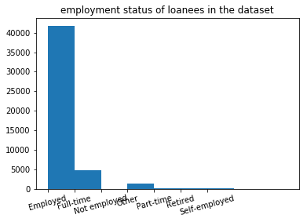

```python
#plt.figure(figsize=[12,8])
base_color=sb.color_palette()[0]

#plt.subplot(2,2,1)
bins = np.arange(0,9+1, 1)
plt.hist(data=loansdata, x='EmploymentStatus', bins=bins)
plt.xticks(rotation=15)
plt.title('employment status of loanees in the dataset');
```

## what special features can you see from the graph above?

> most of the people captured in this dataset are employed either in full time contarct, parttime or self employed with only afew being retired and unemployed. with this we can expect that most of the loans will be paid in since mots people have incomes.

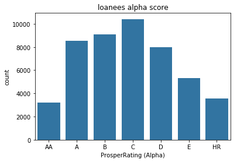

```python
color_base=sb.color_palette()[0]
sb.countplot(data=loansdata, x='ProsperRating (Alpha)', color=color_base)
plt.title('loanees alpha score');
```

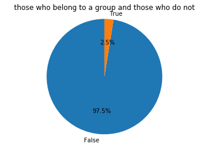

```python
plt.pie(loansdata['CurrentlyInGroup'].value_counts(), labels=loansdata['CurrentlyInGroup'].unique(), autopct='%1.1f%%',
        startangle=90)
plt.axis('equal')
plt.title('those who belong to a group and those who do not');
```

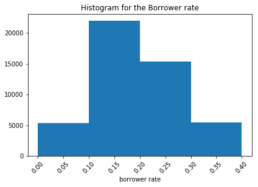

```python
bins=np.arange(0, loansdata.BorrowerRate.max()+0.1, 0.1)
plt.hist(data=loansdata, x="BorrowerRate", bins=bins, color=base_color)
plt.xticks(rotation=45)
plt.tight_layout()
plt.title('Histogram for the Borrower rate')
plt.xlabel('borrower rate')
plt.show()
```

## what are the special features you find in the above visualizations?

> On the univariate plots, we have the borrowrate, this is the borrowers interest rate for their loans.the rate peaks around the 15% rate. we assume the rates are charged based on how risky the transaction is, that is if you have more loans, or bad ratings then the rate will be huge ans viceversa.

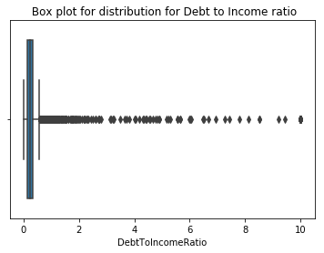

```python
sb.boxplot(x="DebtToIncomeRatio", data=loansdata)
plt.title(' Box plot for distribution for Debt to Income ratio');
```

> from the boxplot we can see that most of the people have a debt to incpome ratio of below 1, meaning that most of the people actually receive a higher income compoared to their debt. this is positive indication as we expect that they will have an easy time paying off their debts. there are however cases of outliers in our data where the debt to income ratio is beyong one and goes upto ten.

## Bivariate Exploration

```python
!pip install --upgrade seaborn
```

[output not shown]

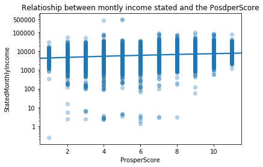

```python
sb.regplot(data=loansdata, y='StatedMonthlyIncome', x='ProsperScore', scatter_kws={'alpha':0.3},color=base_color)
plt.yscale('log')
plt.yticks([10**0, 10**1,10**2,10**3,10**4,10**5,10**5.69897],[1,10,100,1000,10000,100000,500000])
plt.title('Relatioship between montly income stated and the PosdperScore')
plt.show()
```

> Taking a look at various variables in our dataset. we can see a significant relationship that could together affect the main variable. for example. we can see that there is a positive correlation between stated mothly income and the posper score. people who stated that they earn significantly more many tend to have a higher prosper score that those whos stated montly earnings are low.

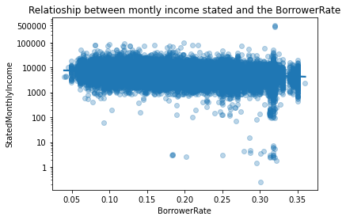

```python
sb.regplot(data=loansdata, x='BorrowerRate', y='StatedMonthlyIncome', scatter_kws={'alpha':0.3},color=base_color)
plt.yscale('log')
plt.yticks([10**0, 10**1,10**2,10**3,10**4,10**5,10**5.69897],[1,10,100,1000,10000,100000,500000])
plt.title('Relatioship between montly income stated and the BorrowerRate')
plt.show()
```

> We can also see the relatioship between the stated monthly income and the borrower rate. we can see that when the stated montly income is high, the borrower rate tends to be low that for those who have stated a low montly income. This further affirms our above statement that there is a positive correlation between stated monthly income and posper score

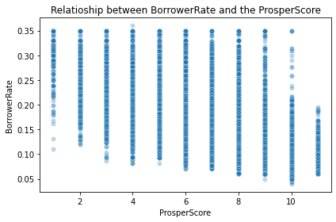

```python
sb.scatterplot(data=loansdata, x='ProsperScore', y='BorrowerRate',alpha=0.3,color=base_color)
# plt.yscale('log')
# plt.yticks([10**0, 10**1,10**2,10**3,10**4,10**5,10**5.69897],[1,10,100,1000,10000,100000,500000])
plt.title('Relatioship between BorrowerRate and the ProsperScore')
plt.tight_layout()
plt.show()
```

> we can see the relationship is negatively correlated. that is to say that when the score is high, the borrower rate is low and vice versa. This is to say that people who have a higher rating jave a low risk when given loans and thus they get the loans at a lower rate as compared to thosw with a low posper score.

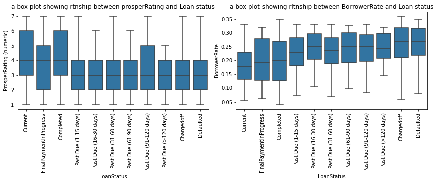

```python
plt.figure(figsize=[12,8])

plt.subplot(2,2,1)
sb.boxplot(data=loansdata, x='LoanStatus', y='ProsperRating (numeric)', color=base_color)
plt.xticks(rotation=90)
plt.title('a box plot showing rtnship between prosperRating and Loan status')

plt.subplot(2,2,2)
sb.boxplot(data=loansdata, x='LoanStatus', y='BorrowerRate', color=base_color)
plt.xticks(rotation=90)
plt.title('a box plot showing rltnship between BorrowerRate and Loan status')
plt.tight_layout()
plt.show()
```

###### what Insights do the box plots above give?

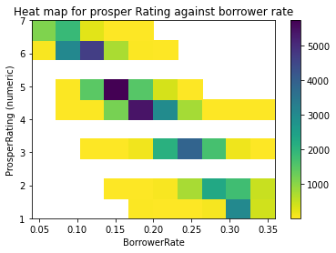

```python
plt.hist2d(data=loansdata, x='BorrowerRate', y='ProsperRating (numeric)', cmin=0.5, cmap='viridis_r')
plt.xlabel('BorrowerRate')
plt.ylabel("ProsperRating (numeric)")
plt.title('Heat map for prosper Rating against borrower rate')
plt.colorbar();
```

> If we look at the relationship between the prosperscore and the loan status, we can see an oustanding same median between the first three statuses, that is the current, in their final payments and those completed. most of them had a higher rating with a nedian score of 4. from those whose loans are past due up to those whose loans have been charged off, the score is low with a median score of 3

### Did you observe any interesting relationships between the other features (not the main feature(s) of interest)?

> Taking a look at various variables in our dataset. we can see a significant relationship that could together affect the main variable. for example. we can see that there is a positive correlation between stated mothly income and the posper score. people who stated that they earn significantly more many tend to have a higher prosper score that those whos stated montly earnings are low.

> We can also see the relatioship between the stated monthly income and the borrower rate. we can see that when the stated montly income is high, the borrower rate tends to be low that for those who have stated a low montly income. This further affirms our above statement that there is a positive correlation between stated monthly income and posper score

## Multivariate Exploration

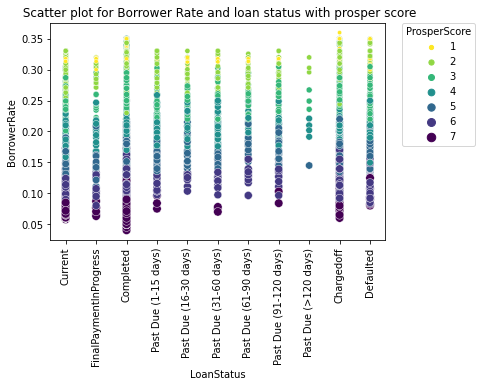

```python
sb.scatterplot(data=loansdata, y='BorrowerRate', x= 'LoanStatus', hue='ProsperRating (numeric)',
               size = 'ProsperRating (numeric)', palette='viridis_r')
plt.xticks(rotation=90)
plt.legend(title = "ProsperScore",bbox_to_anchor=(1.05, 1), loc=2, borderaxespad=0)
plt.title(' Scatter plot for Borrower Rate and loan status with prosper score')
plt.show()
```

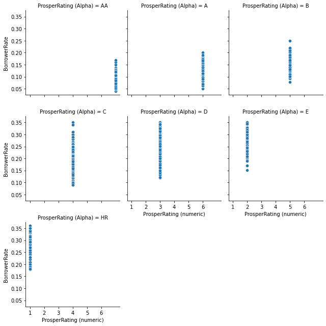

```python
g = sb.FacetGrid(loansdata, col='ProsperRating (Alpha)', col_wrap=3)
g.map(sb.scatterplot, "ProsperRating (numeric)", "BorrowerRate")
plt.xticks([1,2,3,4,5,6],['1','2','3','4','5','6'])
plt.show()
```

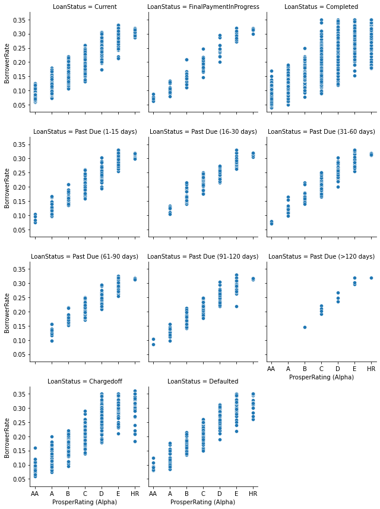

```python
g = sb.FacetGrid(loansdata, col='LoanStatus', col_wrap=3)
g.map(sb.scatterplot, "ProsperRating (Alpha)", "BorrowerRate")
plt.show()
```

> from the visualizations above we can see that there are variable that strengthen each other is this dataset. this variable also have strong effect on our target variable(loasn status)

> looking at the second plot, the facetgrid. we can see that people with an alpha rating of AA have a higher prosper rating score of 7 and get loans at the lowest borrower rate than others. this is then followed with those of alpha rating of A then B and it goes down to HR as seen, they have the lowest prosper rating of 1 and get loans at the highest rates (top right of the last grid)

## Conclusions

> in conclusion, the status of the loans. that is iof one will pay and how sooon they will pay depend on several factores which affect one another. this include the individual earnings, their score and alpha ratings. people who earn more tend to have high prosper ratings and good alpha ratings of AA, A, or B. those who earn less tend to have poor alpha ratings and low prosper ratings. this variables all together tell how likely onme is to paying off their loans in time. those with high income, good alpha ratings and high prosper ratings are most likely to pay off their loans in good time while those with low earnings, poor alpha ratings and low prosper rating are more likely to go beyong the required time to pay their loans or even default.

> to reach to these conclusion some steps had to be taken. this include ordering the categorical data to make the visualisations easy to read and undestand. removing all the null values in tne dataset to avoid having a kisleading visualization caused by the null values and finally some viasualizations had yo be adjusted on the scale to make them fit well in the plotting grid.